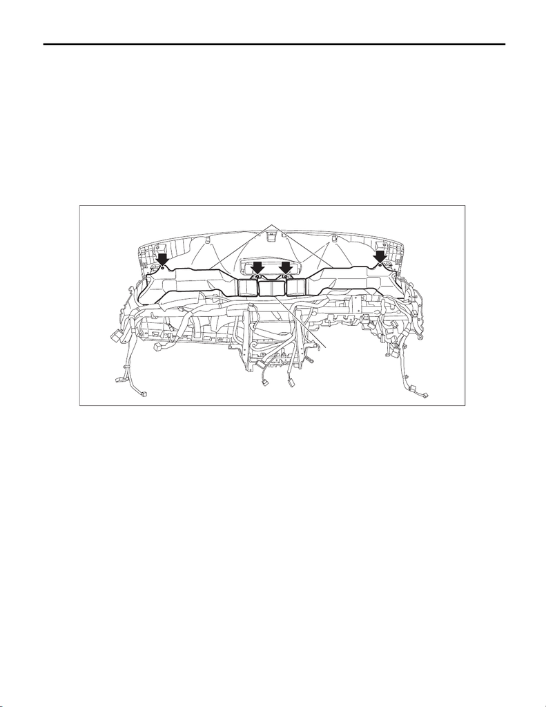

AC-94

Heater Vent Duct

HVAC SYSTEM (HEATER, VENTILATOR AND A/C)

30.Heater Vent Duct

A: REMOVAL

CAUTION:

Before handling the airbag module, refer to “CAUTION” of “General Description” in “AIRBAG SYS-

TEM”. <Ref. to AB-9, CAUTION, General Description.>

1) Disconnect the battery ground cable and wait for at least 60 seconds before starting work. <Ref. to NT-5,

BATTERY, NOTE, Note.>

NOTE:

For models other than STI model, disconnect the ground terminal from battery sensor.

2) Remove the instrument panel assembly. <Ref. to EI-69, REMOVAL, Instrument Panel Assembly.>

3) Remove the screws and remove the duct - center vent (A) and the duct - side ventilation (B) on LH and RH

sides.

B: INSTALLATION

CAUTION:

Before handling the airbag module, refer to “CAUTION” of “General Description” in “AIRBAG SYS-

TEM”. <Ref. to AB-9, CAUTION, General Description.>

1) Install the heater vent duct.

2) Install the instrument panel assembly. <Ref. to EI-77, INSTALLATION, Instrument Panel Assembly.>

3) Connect the battery ground terminal. <Ref. to NT-5, BATTERY, NOTE, Note.>

NOTE:

For models other than STI model, connect the ground terminal to battery sensor.

AC-02725

(B)

(A)